# Lista 3 - Exercício 1 (Mercados incompletos)

### Considerando o modelo padrão de mercados incompletos, responda os itens a seguir:

### (a) Escreva um programa em Python que calcule o equilíbrio recursivo competitivo considerando os seguintes parâmetros: Fator de desconto intertemporal $\beta = 0.98$; função de utilidade CRRA com $\sigma = 2$; taxa de depreciação $\delta = 0.08$; função de produção $f(K, L) = K^\alpha L^{1-\alpha}$, com $\alpha = 0.44$; e matriz de transição dos estados

$$ \pi(y' | y) = \left[ \begin{array}{ccc} 0.4 & 0.5 & 0.1 \\ 0.3 & 0.2 & 0.5 \\ 0.2 & 0.4 & 0.4 \end{array} \right] $$

```python
## Carregando módulos necessários
import numpy as np
import matplotlib.pyplot as plt


## Definição de Parâmetros
beta, sigma = .98, 2
delta, alpha = .08, .44

barA, a_max, n_a = 0, 60, 100
a_grid = np.linspace(-barA, a_max, n_a)

pi = np.array([[.4, .5, .1],
               [.3, .2, .5],
               [.2, .4, .4]])

y_min, y_max, n_y = 1e-2, 1, len(pi)
y_grid = np.linspace(y_min, y_max, n_y)

rho = 1/beta - 1
r_min, r_max = -delta, rho


## Função utilidade CRRA
def U(x, sigma):
    return (x**(1-sigma) - 1) / (1 - sigma)
```

Agora, precisamos realizar:

- Construção da oferta agregada de trabalho, $\bar{L}$, a partir da distribuição estacionária de $\pi$.
- Construção da demanda de capital, $K_r$: \begin{align} F(K, L) &= K^\alpha L^{1 - \alpha} \\ F_K(K, L) &= \alpha K^{(\alpha-1)} L^{1 - \alpha} \\ r + \delta = F_K(K_r, \bar{L}) &= \alpha \left(\frac{\bar{L}}{K_r}\right)^{1 - \alpha} \\ K_r^{(1-\alpha)} &= \frac{\alpha \bar{L}^{1 - \alpha}}{r + \delta} \\ K_r &= \left( \frac{\alpha \bar{L}^{1 - \alpha}}{r + \delta} \right)^{\frac{1}{1-\alpha}} \end{align}
- Cálculo do salário, $w$: \begin{align} F(K, L) &= K^\alpha L^{1 - \alpha} \\ F_L(K, L) &= (1-\alpha) K^{\alpha} L^{-\alpha} \\ w = F_L(K_r, \bar{L}) &= (1-\alpha) \left( \frac{K_r}{\bar{L}} \right)^{\alpha} \end{align}
- Preenchimento da função objetivo e maximização para encontrar funções valor e política
- Construção da função de transição $Q$
- Construão da distribuição estacionária $\bar{\phi}$
- Construção da oferta de capital $\mathbb{E}a$
- Cálculo do excesso de demanda do capital $d_r = K_r - \mathbb{E}_a$

```python
def RCE(beta, sigma):
    """ (beta, sigma) --> (r, K_r, w)  """
    V = np.zeros((n_y, n_a))  # Chute inicial da função valor
    d_path, K_path, Ea_path, r_path = [], [], [], []  # Listas para preenchimento

    r_L, r_H = r_min, r_max
    norma_r, tol_r, it = 1, 1e-6, 0
    while norma_r > tol_r:
        it += 1
        # Atualizando valor de r
        r = (r_L+r_H)/2
        # Criando objeto de L-barra para acumular a oferta de trabalho
        barL = 0


        # Definindo guess inicial para distribuição dos tipos, PI.
        PI_bar = np.ones(n_y)
        PI_bar = PI_bar / sum(PI_bar)  # Normalizando


        # Encontrando a distribuição estacionária
        norm_PI, tol_PI = 1, 1e-4
        while norm_PI > tol_PI:
            PI_prime = np.dot(np.transpose(pi), PI_bar)
            norm_PI = np.max(abs(PI_prime - PI_bar))
            PI_bar = PI_prime[:]  # ou np.copy(PI_prime)


        # Acumulando as ofertas de trabalho por tipo, dada distribuição estacionária PI_bar
        for i_y, y in enumerate(y_grid):
            barL += y * PI_bar[i_y]

        # Construção da demanda de capital
        aux = alpha * barL**(1 - alpha) / (r + delta)
        K_r = aux ** (1 / (1 - alpha))


        # Cálculo do salário
        w = (1 - alpha) * (K_r / barL)**alpha


        # # # # # # # # # # # # # # # # # # # # # # # # # # # # # # # # # # # # # # # # # # #
        # Preenchimento da função objetivo e construção da função valor (Operador de Bellman)
        norm_V, tol_V = 2, 1e-5
        while norm_V > tol_V:

            # Preenchimento da função objetivo
            F_OBJ = np.zeros((n_y, n_a, n_a))
            for i_a, a in enumerate(a_grid):
                for i_y, y in enumerate(y_grid):
                    for i_aa, aa in enumerate(a_grid):

                        # Cálculo do consumo
                        c = w*y + (1+r)*a - aa

                        # Preenchimento na função objetivo
                        if c <= 0:
                            F_OBJ[i_y, i_a, i_aa] = -np.inf
                        else:
                            F_OBJ[i_y, i_a, i_aa] = U(c, sigma) + beta*np.dot(pi[i_y,:], V[:, i_aa])


            # Construção da função valor (Operador de Bellman)
            TV = np.zeros((n_y, n_a))
            iG = np.zeros((n_y, n_a), dtype=np.int64)

            for i_a, a in enumerate(a_grid):
                for i_y, y in enumerate(y_grid):
                    TV[i_y, i_a] = np.max(F_OBJ[i_y, i_a,:])
                    iG[i_y, i_a] = np.argmax(F_OBJ[i_y, i_a,:])

            norm_V = np.max(abs(TV - V))  # Atualizando valor da norma
            V = TV[:]  # Alterando valor de V para próxima iteração


        # # # # # # # # # # # # # # # # # # # # # # # # # # # # # # # # # # # # # # # # # # #
        # Construção da função de transição

        # Empilhando as variáveis de estado em dimensão única
        Q = np.zeros((n_y*n_a, n_y*n_a))  # Importante começar ZERADO!

        # Fixando estado corrente (current)
        for i_y in range(n_y):
            for i_a in range(n_a):
                c_state = i_y*n_a + i_a  # encontrando índice em Q (de dimensão única)

                # Fixando próximo estado (next)
                for i_yy in range(n_y):
                    for i_aa in range(n_a):
                        n_state = i_yy*n_a + i_aa

                        # Verificando se há migração para a' para acumular
                        if i_aa == iG[i_y,i_a]:
                            Q[c_state, n_state] += pi[i_y,i_yy]


        # # # # # # # # # # # # # # # # # # # # # # # # # # # # # # # # # # # # # # # # # # #
        # Construção da distribuição estacionária
        phi_bar = np.ones(n_y * n_a)  # Minúsculo
        phi_bar = phi_bar / sum(phi_bar)  # Normalizando a 1

        norm_phi, tol_phi = 1, 1e-4
        while norm_phi > tol_phi:
            phi_prime = np.dot(np.transpose(Q), phi_bar)
            norm_phi = np.max(abs(phi_prime - phi_bar))
            phi_bar = phi_prime[:]


        # # # # # # # # # # # # # # # # # # # # # # # # # # # # # # # # # # # # # # # # # # #
        # Construção da oferta de capital Ea
        Ea_r = 0

        for i_a, a in enumerate(a_grid):
            for i_y, y in enumerate(y_grid):
                c_state = i_a + (n_a * i_y)
                i_aa = iG[i_y, i_a]
                aa = a_grid[i_aa]
                Ea_r += aa * phi_bar[c_state]


        # # # # # # # # # # # # # # # # # # # # # # # # # # # # # # # # # # # # # # # # # # #
        # Construção do excesso de demanda do capital
        d_r = K_r - Ea_r


        # # # # # # # # # # # # # # # # # # # # # # # # # # # # # # # # # # # # # # # # # # # #
        # # Guardando os resultados
        d_path.append(d_r)
        K_path.append(K_r)
        Ea_path.append(Ea_r)
        r_path.append(r)

        if d_r > 0:
            r_L = r
        elif d_r < 0:
            r_H = r

        norma_r = r_H - r_L
#         print('it {:2d}, norma_r = {:3.10f}, d_r = {:3.10f}'.format(it, norma_r, d_r))

    return r, K_r, w
```

```python
# Usando a função construída para resolver o problema
r_ss, K_r_ss, w_ss = RCE(beta, sigma)

# print some info
print("-"*100)
print(" The interest rate is:", r_ss)
print("\n The capital-labor rate is:", K_r_ss)  # Aqui deveria ser valor de k
print("\n The wage rate is:", w_ss)
print("-"*100)
```

```
----------------------------------------------------------------------------------------------------
 The interest rate is: 0.00964587776028382

 The capital-labor rate is: 9.097204337869963

 The wage rate is: 1.9545896273741732
----------------------------------------------------------------------------------------------------
```

### (b) Relate como a taxa de juros de equilíbrio depende do fator de desconto intertemporal $\beta$ e da taxa de substituição intertemporal/aversão ao risco $\sigma$.

```
[0.7     0.02041]
[0.84    0.02041]
[0.98    0.00965]
```

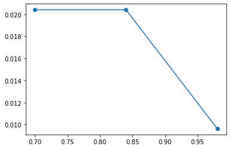

```python
beta_grid = np.linspace(0.7, 0.98, 3)
tab_beta = np.zeros((len(beta_grid), 2))

for i_beta, beta in enumerate(beta_grid):
    tab_beta[i_beta, 0] = beta
    tab_beta[i_beta, 1] = RCE(beta, sigma)[0]
    print(np.round(tab_beta[i_beta], 5))

plt.plot(tab_beta[:, 0], tab_beta[:, 1], "o-")
```

```
[0.5     0.01865]
[1.25    0.01588]
[2.      0.00965]
```

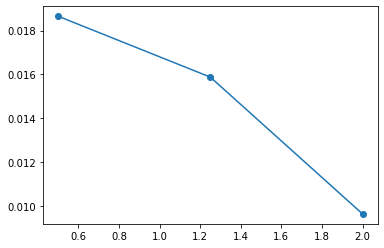

```python
sigma_grid = np.linspace(0.5, 2, 3)
tab_sigma = np.zeros((len(sigma_grid), 2))

for i_sigma, sigma in enumerate(sigma_grid):
    tab_sigma[i_sigma, 0] = sigma
    tab_sigma[i_sigma, 1] = RCE(beta, sigma)[0]
    print(np.round(tab_sigma[i_sigma], 5))

plt.plot(tab_sigma[:, 0], tab_sigma[:, 1], "o-")
```

### (c) Escolha um conjunto de parâmetros e escreva um programa em Python que calcule o equilíbrio recursivo competitivo permitindo que a escolha do ativo $a'$ seja contínua.

##### Exemplo: Interpolação e Maximização

```
Para maximizar y precisamos de x = 4.000000067578451
```

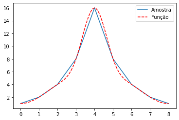

```python
from scipy.optimize import minimize
from scipy.interpolate import interp1d

## Gerando e visualizando x e y
x = np.array([0, 1, 2, 3,  4, 5, 6, 7, 8])
y = np.array([1, 2, 4, 8, 16, 8, 4, 2, 1])

## Interpolando a partir do x e y dados
f_interp = interp1d(x, -y, kind='cubic')  # -y, pois iremos maximizar
x_test = np.linspace(0, 8, 101)
y_test = -f_interp(x_test)

## Comparando amostra com a função criada (101 pontos)
plt.plot(x, y, label="Amostra")  # amostra original
plt.plot(x_test, y_test, "r--", label="Função")
plt.legend()

# Otimização via minimização
guess = [1]  # chute inicial
optim = minimize(f_interp, x0=guess, method='BFGS')
print("Para maximizar y precisamos de x =", optim.x[0])
```

##### Resolução do item (c): Não finalizado

```python
## Carregando módulos necessários
import numpy as np
import matplotlib.pyplot as plt
from scipy.optimize import minimize
from scipy.optimize import minimize_scalar
from scipy.interpolate import interp1d


## Definição de Parâmetros
beta, sigma = .98, 2
delta, alpha = .08, .44

barA, a_max, n_a = 0, 5, 50
a_grid = np.linspace(-barA, a_max, n_a)

pi = np.array([[.4, .5, .1],
               [.3, .2, .5],
               [.2, .4, .4]])

y_min, y_max, n_y = 1e-2, 1, len(pi)
y_grid = np.linspace(y_min, y_max, n_y)

rho = 1/beta - 1
r_min, r_max = -delta, rho


## Função utilidade CRRA
def U(x):
    return (x**(1-sigma) - 1) / (1 - sigma)


""" (beta, sigma) --> (r, K_r, w)  """
V = np.zeros((n_y, n_a))  # Chute inicial da função valor
d_path, K_path, Ea_path, r_path = [], [], [], []  # Listas para preenchimento

r_L, r_H = r_min, r_max
norma_r, tol_r, it = 1, 1e-6, 0
while norma_r > tol_r:
    it += 1
    # Atualizando valor de r
    r = (r_L+r_H)/2
    # Criando objeto de L-barra para acumular a oferta de trabalho
    barL = 0


    # Definindo guess inicial para distribuição dos tipos, PI.
    PI_bar = np.ones(n_y)
    PI_bar = PI_bar / sum(PI_bar)  # Normalizando


    # Encontrando a distribuição estacionária
    norm_PI, tol_PI = 1, 1e-4
    while norm_PI > tol_PI:
        PI_prime = np.dot(np.transpose(pi), PI_bar)
        norm_PI = np.max(abs(PI_prime - PI_bar))
        PI_bar = PI_prime[:]  # ou np.copy(PI_prime)


    # Acumulando as ofertas de trabalho por tipo, dada distribuição estacionária PI_bar
    for i_y, y in enumerate(y_grid):
        barL += y * PI_bar[i_y]

    # Construção da demanda de capital
    aux = alpha * barL**(1 - alpha) / (r + delta)
    K_r = aux ** (1 / (1 - alpha))


    # Cálculo do salário
    w = (1 - alpha) * (K_r / barL)**alpha


    # # # # # # # # # # # # # # # # # # # # # # # # # # # # # # # # # # # # # # # # # # #
    # Preenchimento da função objetivo e construção da função valor (Operador de Bellman)
    norm_V, tol_V = 2, 1e-5
    while norm_V > tol_V:

        # Preenchimento da função objetivo
        for i_a, a in enumerate(a_grid):
            for i_y, y in enumerate(y_grid):
                TV = np.zeros((n_y, n_a))
                G = np.zeros((n_y, n_a))

                # Interpolação - uma função para cada y
                f_V_y0 = interp1d(a_grid, V[0,:], kind='cubic')
                f_V_y1 = interp1d(a_grid, V[1,:], kind='cubic')
                f_V_y2 = interp1d(a_grid, V[2,:], kind='cubic')


                def f_OBJ(x):
                    EV = np.dot(pi[i_y,:], [float(f_V_y0(x)), float(f_V_y1(x)), float(f_V_y2(x))])
                    return (-1) * (w*y + (1+r)*a - x + beta * EV)  # -1 p/ maximizar

                # Testando
                for i, a in enumerate(a_grid):
                    print(np.round(a, 4), "", np.round(f_OBJ(a), 4))

                # Maximizando
                guess = np.mean(a_grid)
                optim = minimize_scalar(f_OBJ, method="bounded", bounds=(-barA, a_max))

                V = f_OBJ(optim.x)
                G = optim.x


        norm_V = np.max(abs(TV - V))  # Atualizando valor da norma
        V = TV[:]  # Alterando valor de V para próxima iteração


    # # # # # # # # # # # # # # # # # # # # # # # # # # # # # # # # # # # # # # # # # # #
    # Construção da função de transição

    # Empilhando as variáveis de estado em dimensão única
    Q = np.zeros((n_y*n_a, n_y*n_a))  # Importante começar ZERADO!

    # Fixando estado corrente (current)
    for i_y in range(n_y):
        for i_a in range(n_a):
            c_state = i_y*n_a + i_a  # encontrando índice em Q (de dimensão única)

            # Fixando próximo estado (next)
            for i_yy in range(n_y):
                for i_aa in range(n_a):
                    n_state = i_yy*n_a + i_aa

                    # Verificando se há migração para a' para acumular
                    if i_aa == iG[i_y,i_a]:
                        Q[c_state, n_state] += pi[i_y,i_yy]


    # # # # # # # # # # # # # # # # # # # # # # # # # # # # # # # # # # # # # # # # # # #
    # Construção da distribuição estacionária
    phi_bar = np.ones(n_y * n_a)  # Minúsculo
    phi_bar = phi_bar / sum(phi_bar)  # Normalizando a 1

    norm_phi, tol_phi = 1, 1e-4
    while norm_phi > tol_phi:
        phi_prime = np.dot(np.transpose(Q), phi_bar)
        norm_phi = np.max(abs(phi_prime - phi_bar))
        phi_bar = phi_prime[:]


    # # # # # # # # # # # # # # # # # # # # # # # # # # # # # # # # # # # # # # # # # # #
    # Construção da oferta de capital Ea
    Ea_r = 0

    for i_a, a in enumerate(a_grid):
        for i_y, y in enumerate(y_grid):
            c_state = i_a + (n_a * i_y)
            i_aa = iG[i_y, i_a]
            aa = a_grid[i_aa]
            Ea_r += aa * phi_bar[c_state]


    # # # # # # # # # # # # # # # # # # # # # # # # # # # # # # # # # # # # # # # # # # #
    # Construção do excesso de demanda do capital
    d_r = K_r - Ea_r


    # # # # # # # # # # # # # # # # # # # # # # # # # # # # # # # # # # # # # # # # # # # #
    # # Guardando os resultados
    d_path.append(d_r)
    K_path.append(K_r)
    Ea_path.append(Ea_r)
    r_path.append(r)

    if d_r > 0:
        r_L = r
    elif d_r < 0:
        r_H = r

    norma_r = r_H - r_L
    print('iteration {:3d}, norma_r = {:3.10f}'.format(it, norma_r))
```

[output not shown]

[output not shown]